# Metropolis’ Algorithm

Eloy

25/2/2022

## Description of the algorithm.

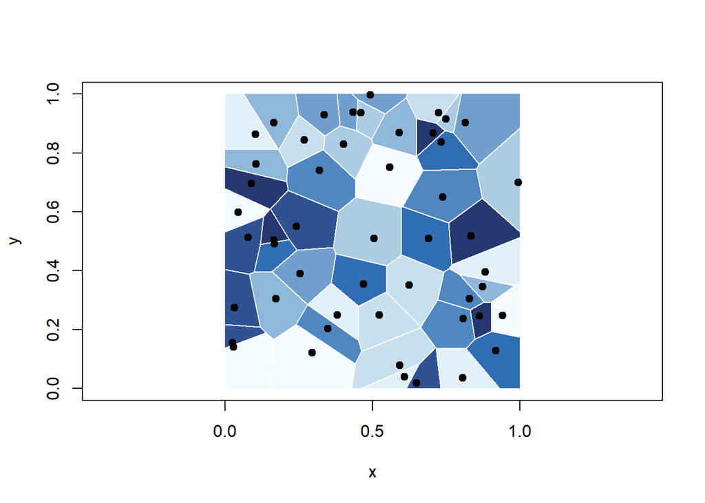

Once the energy has been calculated, the algorithm starts randomly changing points, calculates the energy associated with the new tessellation, and decides whether to accept the new tessellation or not.

## Algorithm in a cylindrical domain

As we want to apply the Metropolis algorithm on the surface of a cylinder, we have to make some modifications to ensure some conditions on the contours of the cells, because now the points near the left edge are close to those on the right edge. Therefore the computational solution is to make 2 replicas of the points and work only (i.e. calculate the energy) with those Voronoi regions that have associated points within the central region. This is clearly seen in the graph below.

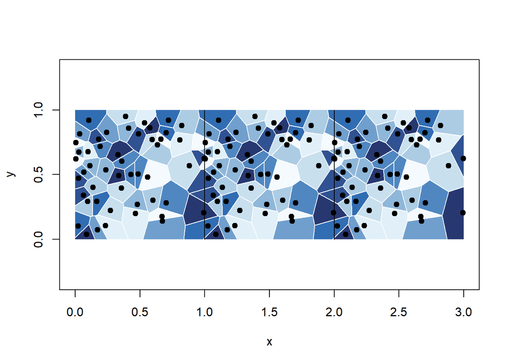

## Construction and explanation of the algorithm

```r
changepoint3<-function(pt){
  ind<-sample(1:n,1)
  ptinx<-pt$x[ind]+rnorm(1,mean=0,sd=r)
  ptiny<-pt$y[ind]+rnorm(1,mean=0,sd=r)
  while((ptinx<xmin || ptinx>xmax)||(ptiny<ymin || ptiny>ymax)){
    ptinx<-pt$x[ind]+runif(1,min=-r,max=r)
    ptiny<-pt$y[2]+runif(1,min=-r,max=r)
  }
  pt$x[c(ind,ind+n,ind+2*n)]<-c(ptinx,ptinx+wid,ptinx+2*wid)
  pt$y[c(ind,ind+n,ind+2*n)]<-ptiny
  return(pt)
}
```

The following two functions calculate the energy associated with a tessellation, the first after passing the tessellation as a parameter, and the second only by passing the points.

```r
energytes<-function(tile){
  perim<-tilePerim(tile)$perimeters
  energycell<-c()
  energyt<-c(0)
  for (i in 1:length(tile)){
    energycell[i]<-((k/2)*(((tile[[i]]$area)-A0)^2)) #+(gam/2)*(perim[[i]])^2+lambda*perim[[i]]
  }
  energyt<-sum(energycell)
  return(energyt)
}

teselandenergy3<-function(xt,yt){
  tesel<-deldir(xt,yt,rw=rec)
  tilest<-tile.list(tesel)[(n+1):(2*n)]
  tesener<-energytes(tilest)
  return(tesener)
}
```

Then it is necessary to decide whether or not to accept the tessellation. To do this, the following function evaluates the difference in energies, and decides whether we accept the change (in which case it returns $1$) or not (and returns $0$).

```r
choice<-function(delta){
  if(delta<=0){p<-1}else if(exp(-delta*bet)==Inf){p<-0}else{p<-exp(-delta*bet)}

  a=sample(c(0,1), size = 1,replace=TRUE, prob = c(1-p,p))
  return(a)
}
```

Finally, the following function returns a graph of the Voronoi tessellation associated with the points we enter.

```r
ggplotvor<-function(plotpoints,tit){
  rectangle <- data.frame(x=c(xmin,xmin,xmax+2*wid,xmax+2*wid),y=c(ymin,ymax,ymax,ymin))
  pl <- ggplot(plotpoints,aes(x,y)) +
    geom_voronoi(aes(fill=as.factor(y)),size=.125, outline = rectangle,show.legend = FALSE) +
    geom_vline(xintercept = xmax,color = 'white',linetype='solid',size=1) +
    geom_vline(xintercept = xmax+wid,color = 'white',linetype='solid',size=1) +
    stat_voronoi(geom="path",outline = rectangle) +
    geom_point(size=2) +
    theme(
      panel.grid.major = element_blank() # Remove gridlines (major)
      ,panel.grid.minor = element_blank() # Remove gridlines (minor)
      ,panel.background = element_blank() # Remove grey background
      ,plot.title = element_text(hjust = 0, size = 20, colour = "#323232") # Title size and colour
      ,plot.caption = element_text(vjust = 0.3, size = 11, colour = "#323232") # Caption size and colour
      ,axis.ticks.y = element_blank() # Remove tick marks (Y-Axis)
      ,axis.text.y =  element_blank() # Remove scale marks (Y-Axis)
      ,axis.title.y = element_blank() # Remove axis label (Y-Axis)
      ,axis.ticks.x = element_blank() # Remove tick marks (X-Axis)
      ,axis.text.x  = element_blank() # Remove axis scale (X-Axis)
      ,axis.title.x = element_blank() # Remove axis label (X-Axis)
      ,legend.position="bottom"
    ) +
    labs(title = tit # Title text
         ,caption = "Author: Eloy Serrano        ")
  show(pl)
}
```

### Code

Now let’s look at the code of the algorithm itself. First we initialize the constants we will need.

```r
k<-1
gam<-1
lambda<-1
xmin<-0
ymin<-0
xmax<-10
ymax<-10
wid<-xmax-xmin
n<-40

r<- wid*2/n #radio en que cambiamos el punto
bet<-10
pasos<-1


A0<-(wid*(ymax-ymin))/n
```

Then, we take random points in the rectangle and calculate the Voronoi tessellation and the associated energy. We save the initial points in *pointsinit,* and create the variable *energhist* in which we will store the energies of each step of the algorithm.

```r
x1 <- runif(n,xmin,xmax)
y1 <- runif(n,ymin,ymax)

x<-c(x1,x1+wid,x1+2*wid)
y<-c(y1,y1,y1)
points<-data.frame(x=x,y=y)

pointsinitmetv1<-points

rec<-c(xmin,xmin+3*wid,ymin,ymax)

teselacion <- deldir(points$x,points$y,rw=rec)
tiles <- tile.list(teselacion)
tilescyl<-tiles[(n+1):(2*n)]
energytesel<-energytes(tilescyl)
energyinit<-energytesel
energhist<-data.frame(iteration=0,energy=energyinit)

histpts<-list()
```

Once the initial tessellation has been calculated, with the help of the functions defined above, we create a *for* loop that iterates according to Metropolis.

```r
for (j in 1:pasos) {
  for(l in 1:n) {
    points2<-changepoint3(points)
    energytesel2<-teselandenergy3(points2$x,points2$y)
    c<-choice(energytesel2-energytesel)
    if(c==1){
      points<-points2
      energytesel<-energytesel2
      histpts[[j*l]]<-list(points,energytesel)
    }
  }
    energhist[j+1,c(1,2)]<-c(j,energytesel)
}
energymetropolis1<-energhist
pointsmetv1<-points
energyinit
```

```
## [1] 28.62994
```

```r
energytesel
```

```
## [1] 15.86163
```

```r
histpts<-Filter(Negate(is.null), histpts)
```

Once the algorithm is finished, we plot the graphs we are interested in

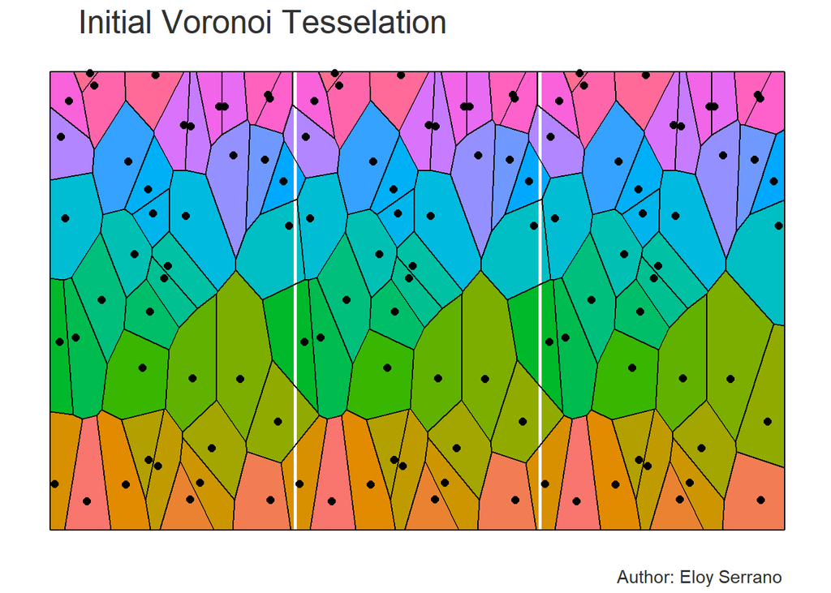

```r
ggplotvor(pointsinitmetv1, "       Initial Voronoi Tesselation")
```

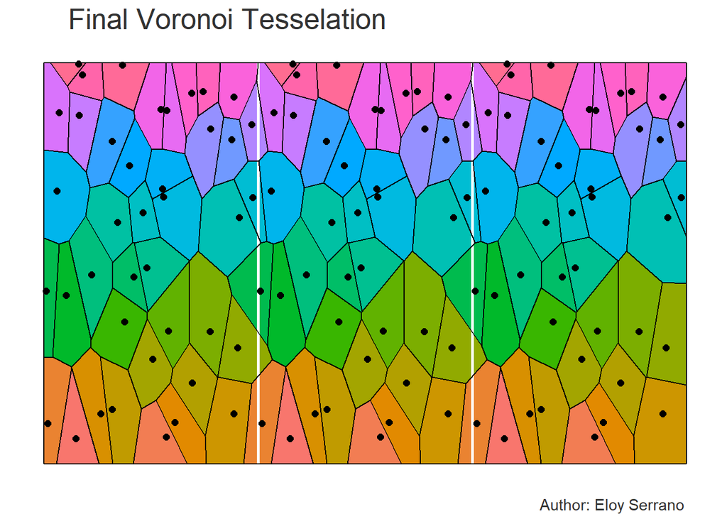

```r
ggplotvor(pointsmetv1,"       Final Voronoi Tesselation")
```

```r
#areasideplots(points)
#plotenergy(energhist)
```

## Second version of the algorithm.

This other version of the algorithm, in each step, changes all the points of the tessellation, unlike the first version, which also made $n$ changes but not necessarily of all the places. To do this, we modify the function that moves the points.

```r
changepoint3_alg2<-function(pt,ind){
  ptinx<-pt$x[ind]+rnorm(1,mean=0,sd=r)
  ptiny<-pt$y[ind]+rnorm(1,mean=0,sd=r)
  while((ptinx<xmin || ptinx>xmax)||(ptiny<ymin || ptiny>ymax)){
    ptinx<-pt$x[ind]+rnorm(1,mean=0,sd=r)
    ptiny<-pt$y[ind]+rnorm(1,mean=0,sd=r)
  }
  pt$x[c(ind,ind+n,ind+2*n)]<-c(ptinx,ptinx+wid,ptinx+2*wid)
  pt$y[c(ind,ind+n,ind+2*n)]<-ptiny
  return(pt)
}
```

The rest of the algorithm is the same, and we have the following code.

```r
rm(x1,x,y1,y,points,teselacion,tiles,tilescyl,energytesel,energyinit,energhist,histpts)
x1 <- runif(n,xmin,xmax)
y1 <- runif(n,ymin,ymax)
x<-c(x1,x1+wid,x1+2*wid)
y<-c(y1,y1,y1)
points<-data.frame(x=x,y=y)

pointsinitmetv2<-points

rec<-c(xmin,xmin+3*wid,ymin,ymax)

teselacion <- deldir(points$x,points$y,rw=rec)
tiles <- tile.list(teselacion)
tilescyl<-tiles[(n+1):(2*n)]
energytesel<-energytes(tilescyl)
energyinit<-energytesel
energhist<-data.frame(iteration=0,energy=energyinit)

histpts<-list()

for (j in 1:pasos) {
  for(l in 1:n) {
    points2<-changepoint3_alg2(points,l)
    energytesel2<-teselandenergy3(points2$x,points2$y)
    c<-choice(energytesel2-energytesel)
    if(c==1){
      points<-points2
      energytesel<-energytesel2
      histpts[[j*l]]<-list(points,energytesel)
    }
  }
  energhist[j+1,c(1,2)]<-c(j,energytesel)
}
energymetropolis2<-energhist
energyinit
```

```
## [1] 28.69147
```

```r
energytesel
```

```
## [1] 17.08501
```

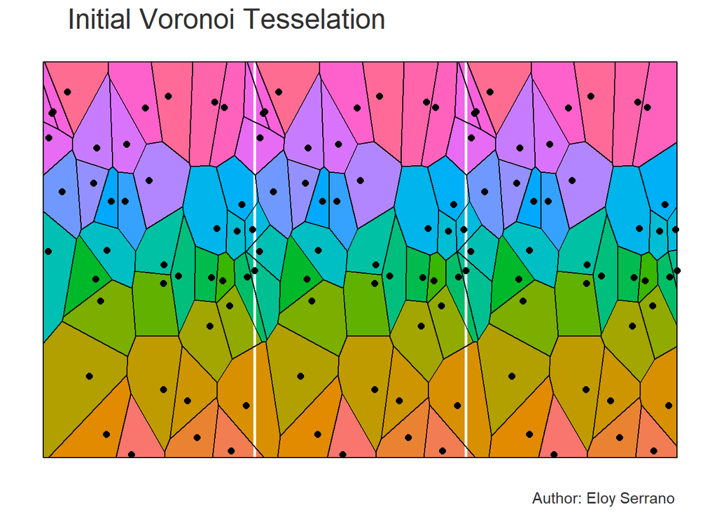

```r
pointsmetv2<-points


ggplotvor(pointsinitmetv2, "       Initial Voronoi Tesselation")
```

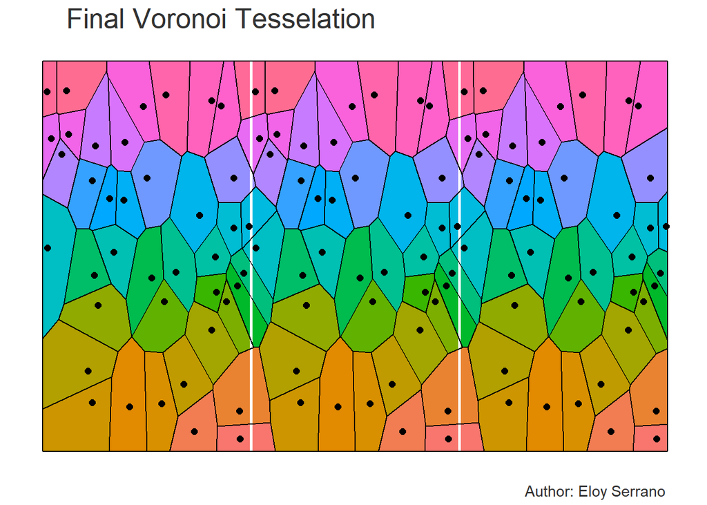

```r
ggplotvor(pointsmetv2,"       Final Voronoi Tesselation")
```

In order to compare the two algorithms, we create the following function, which takes two vectors that store the energy and plots them.

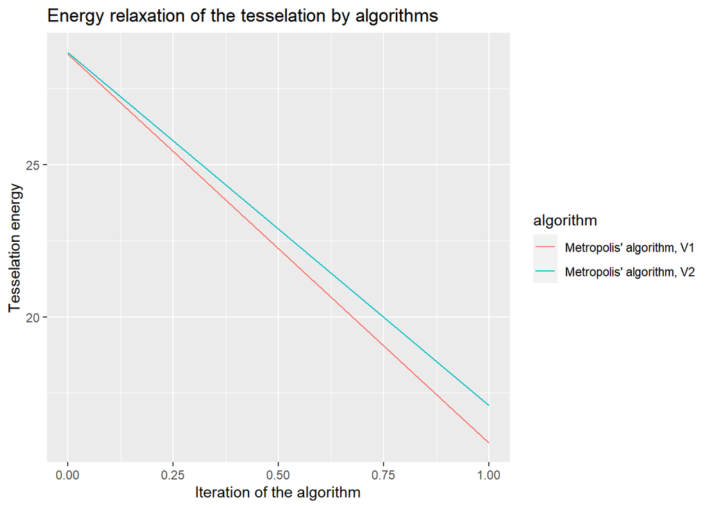

```r
library(ggplot2)
plotcompener<-function(en1,en2,name1,name2){
  #After introducing the energy vector of lloyd and metropolis algorithm,
  #this function makes the combined plot of both energies.
  m=length(en1$iteration)
  energy<-en1
  energy[(m+1):(2*m),c(1,2)]<-en2
  energy[1:m,3]<-name1
  energy[(m+1):(2*m),3]<-name2
  colnames(energy)<-c("iteration","energy","algorithm")

  p<-ggplot(energy,aes(x=iteration, y=energy, color=algorithm))+
    geom_line()+
    xlab("Iteration of the algorithm")+
    ylab("Tesselation energy")+
    ggtitle("Energy relaxation of the tesselation by algorithms")
  show(p)
}
plotcompener(energymetropolis1,energymetropolis2,"Metropolis' algorithm, V1","Metropolis' algorithm, V2")
```

## Comparison with Lloyd’s algorithm.

```r
lloydpoints<-function(x){
  if(x-wid>xmax){x<-x-wid}else if(x-wid<xmin){x<-x+wid}else{x}
}

x1 <- runif(n,xmin,xmax)
y1 <- runif(n,ymin,ymax)

x<-c(x1,x1+wid,x1+2*wid)
y<-c(y1,y1,y1)
points<-data.frame(x=x,y=y)

ptsinitx<-x
ptsinity<-y
pointsinit<-data.frame(x=ptsinitx,y=ptsinity)

rec<-c(xmin,xmin+3*wid,ymin,ymax)

teselacion <- deldir(points$x,points$y,rw=rec)
tiles <- tile.list(teselacion)
tilescyl<-tiles[(n+1):(2*n)]
energytesel<-energytes(tilescyl)
energyinit<-energytesel
energhist<-data.frame(iteration=0,energy=energyinit)

for (j in 1:pasos) {
  teselacion <- deldir(points$x,points$y,rw=rec)
  tiles <- tile.list(teselacion)
  tilescyl<-tiles[(n+1):(2*n)]
  energytesel<-energytes(tilescyl)
  energhist[j+1,c(1,2)]<-c(j,energytesel)

  centroids<-tile.centroids(tiles)[(n+1):(2*n),c(1,2)]
  centroids$x<-unlist(sapply(centroids$x,lloydpoints))
  centroids1<-centroids
  centroids1$x<-centroids1$x-wid
  centroids2<-centroids
  centroids2$x<-centroids$x+wid
  points[1:n,c(1,2)]<-centroids1
  points[(n+1):(2*n),c(1,2)]<-centroids
  points[(2*n+1):(3*n),c(1,2)]<-centroids2
}
pointslloyd<-points
energylloyd<-energhist
energyinit
```

```
## [1] 42.73068
```

```r
energytesel
```

```
## [1] 42.73068
```

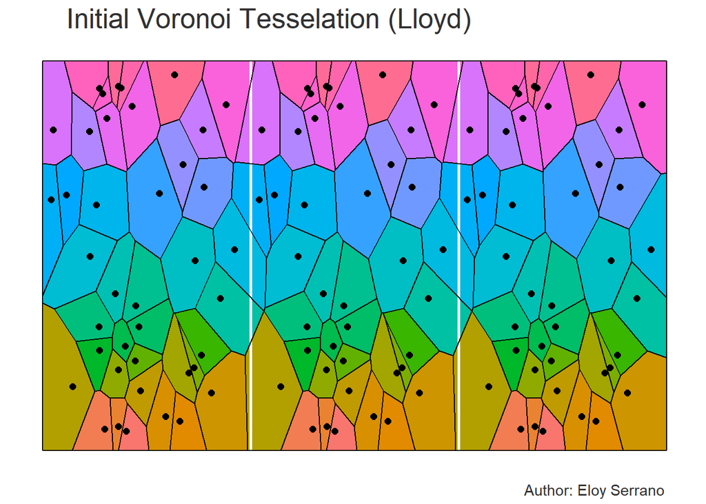

```r
ggplotvor(pointsinit,"       Initial Voronoi Tesselation (Lloyd)")
```

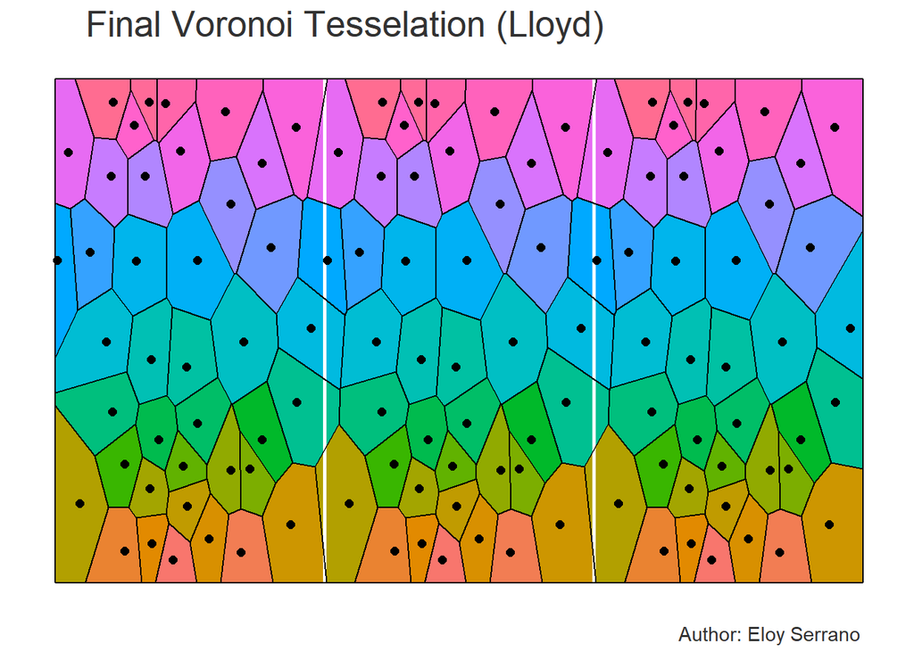

```r
ggplotvor(pointslloyd,"       Final Voronoi Tesselation (Lloyd)")
```

Furthermore, with the function described above, we can compare the Lloyd’s algorithm with the Metropolis algorithm.

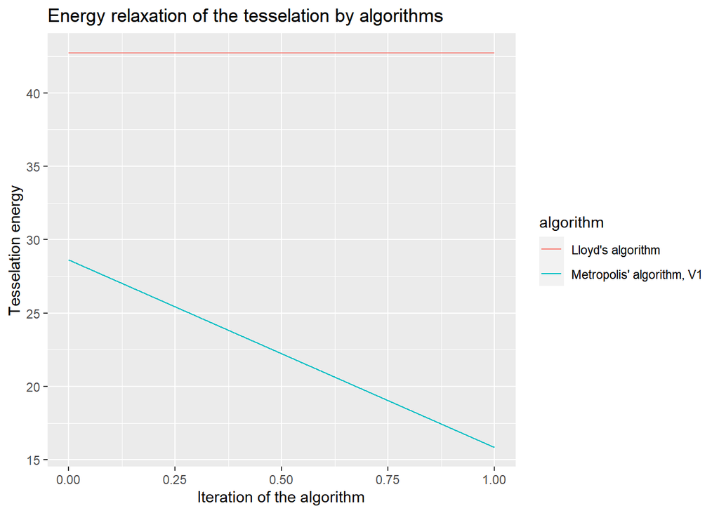

```r
plotcompener(energylloyd,energymetropolis1,"Lloyd's algorithm","Metropolis' algorithm, V1")
```

## Graphics associated with tessellation.

To study the results, it is important to see if Lewis’ law, which says that the area of the cells is proportional to the number of sides, is fulfilled. We also want to study the distribution of the number of sides of each cell. To do this, we create the following function.

```r
areasideplots<-function(xy){
  tsl<-deldir(xy$x,xy$y,rw=rec)
  til<-tile.list(tsl)
  #Lwlw<-lawSummary(tsl)
  #option1
  celledgearea<-data.frame()
  for (i in 1:length(til)) {
    celledgearea[i,c(1,2)]<-c(length(til[[i]]$x),til[[i]]$area/A0)
  }
  #option2
  #celledgearea<-data.frame(Lwlw$num.edges,Lwlw$tile.areas/A0)
  colnames(celledgearea)<-c("edges","area")
  plotareaedges<-ggplot(celledgearea, aes(x = edges, y = area, colour = area))+
    geom_point()+xlab("Number of sides")+ylab("Relative area")+
    ggtitle("Relative area of the cells by sides")+
    stat_summary(aes(y = area,group=1), fun=mean, colour="#00BFC4", geom="line",group=1)
  show(plotareaedges)

  histedges<-ggplot(celledgearea,aes(edges))+geom_histogram(colour="#F8766D" ,fill="#7CAE00",bins=10,alpha=0.6)+
    xlab("Number of edges")+ylab("Frequency")+
    ggtitle("Quantity of sides of the cells")+
    xlim(2,11)
  show(histedges)

}
```

It is also interesting to see the Voronoi tessellation corresponding to the lowest energy of the system. For this we create the following function.

```r
plotminener<-function(histpt){
  #Lets draw the tesselation corresponding with minimum energy
  energhist<-list()
  for (i in 1:length(histpt)) {
    energhist[[i]]<-histpt[[i]][[2]]
  }
  indmin<-which.min(unlist(energhist))
  ptsmin<-histpt[[indmin]][[1]]
  plotvor3(ptsmin$x,ptsmin$y)
}
```